# 基于贝叶斯理论的垃圾邮件分类法（实验报告）

本次作业以垃圾邮件分类任务为基础，要求提取文本特征并使用朴素贝叶斯算法进行垃圾邮件识别（调用已有工具包或自行实现）。

### 任务介绍

电子邮件是互联网的一项重要服务，在大家的学习、工作和生活中会广泛使用。但是大家的邮箱常常被各种各样的垃圾邮件填充了。有统计显示，每天互联网上产生的垃圾邮件有几百亿近千亿的量级。因此，对电子邮件服务提供商来说，垃圾邮件过滤是一项重要功能。而朴素贝叶斯算法在垃圾邮件识别任务上一直表现非常好，至今仍然有很多系统在使用朴素贝叶斯算法作为基本的垃圾邮件识别算法。

本次实验数据集来自[Trec06](https://plg.uwaterloo.ca/cgi-bin/cgiwrap/gvcormac/foo06)的中文垃圾邮件数据集，目录解压后包含三个文件夹，其中data目录下是所有的邮件（未分词），已分词好的邮件在data_cut目录下。邮件分为邮件头部分和正文部分，两部分之间一般有空行隔开。标签数据在label文件夹下，文件中每行是标签和对应的邮件路径。‘spam’表示垃圾邮件，‘ham’表示正常邮件。

基本要求：

1. 提取正文部分的文本特征；
2. 划分训练集和测试集（可以借助工具包。一般笔记本就足够运行所有数据，认为实现困难或算力不够的同学可以采样一部分数据进行实验。）；
3. 使用朴素贝叶斯算法完成垃圾邮件的分类与预测，要求测试集准确率Accuracy、精准率Precision、召回率Recall均高于0.9（本次实验可以使用已有的一些工具包完成如sklearn）；
4. 对比特征数目（词表大小）对模型效果的影响；
5. 提交代码和实验报告。

扩展要求：

1. 邮件头信息有时也可以协助判断垃圾邮件，欢迎学有余力的同学们尝试；
2. 尝试自行实现朴素贝叶斯算法细节；
3. 尝试对比不同的概率计算方法。

### 导入工具包

```python
import os
import jieba
import pandas as pd
import numpy as np
from sklearn.feature_extraction.text import CountVectorizer
from sklearn.model_selection import RandomizedSearchCV,train_test_split
from sklearn.svm import LinearSVC
from sklearn.naive_bayes import MultinomialNB, BernoulliNB, ComplementNB, GaussianNB
from sklearn.metrics import accuracy_score, precision_score, recall_score, confusion_matrix, roc_curve,auc
from scipy.stats import uniform
import matplotlib.pyplot as plt
```

```python
class EmailToWordFeatures:
    '''
    "将邮件转换为特征词矩阵"

    整个过程包括：
    - 对邮件内容进行分词处理
    - 去除所有非中文字符，如标点符号、英文字符、数字、网站链接等特殊字符
    - 过滤停用词
    - 创建特征矩阵

    '''
    def __init__(self,stop_word_file=None,features_vocabulary=None):

        self.features_vocabulary = features_vocabulary

        self.stop_vocab_dict = {}  # 初始化停用词
        if stop_word_file is not None:
            self.stop_vocab_dict = self._get_stop_words(stop_word_file)

    def text_to_feature_matrix(self,words,vocabulary=None,threshold =10):
        cv = CountVectorizer()
        if vocabulary is None:
            cv.fit(words)
        else:
            cv.fit(vocabulary)
        words_to_vect = cv.transform(words)
        words_to_matrix = pd.DataFrame(words_to_vect.toarray())  # 转换成索引矩阵
        print(words_to_matrix.shape)

        # 进行训练特征词选择，给定一个阈值，当单个词在所有邮件中出现的次数的在阈值范围内时及选为训练特征词、
        selected_features = []
        selected_features_index = []
        for key,value in cv.vocabulary_.items():
            if words_to_matrix[value].sum() >= threshold:  # 词在每封邮件中出现的次数与阈值进行比较
                selected_features.append(key)
                selected_features_index.append(value)
        words_to_matrix.rename(columns=dict(zip(selected_features_index,selected_features)),inplace=True)
        return words_to_matrix[selected_features]

    def get_email_words(self,email_path, max_email = 600):
        '''
        由于机器配置问题，作为测试给定阈值600，及正负样本数各位600
        '''
        self.emails = email_path
        if os.path.isdir(self.emails):
            emails = os.listdir(self.emails)
            is_dir = True
        else:
            emails = [self.emails,]
            is_dir = False

        count = 0
        all_email_words = []
        for email in emails:
            if count >= max_email:  # 给定读取email数量的阈值
                break
            if is_dir:
                email_path = os.path.join(self.emails,email)
            email_words = self._email_to_words(email_path)
            all_email_words.append(' '.join(email_words))
            count += 1
        return all_email_words

    def _email_to_words(self, email):
        '''
        将邮件进行分词处理，去除所有非中文和停用词
        retrun:words_list
        '''
        email_words = []
        with open(email, 'rb') as pf:
            for line in pf.readlines():
                line = line.strip().decode('gbk','ignore')
                if not self._check_contain_chinese(line):  # 判断是否是中文
                    continue
                word_list = jieba.cut(line, cut_all=False)  # 进行分词处理
                for word in word_list:
                    if word in self.stop_vocab_dict or not self._check_contain_chinese(word):
                        continue  # 判断是否为停用词
                    email_words.append(word)
            return email_words

    def _get_stop_words(self,file):
        '''
        获取停用词
        '''
        stop_vocab_dict = {}
        with open(file,'rb') as pf:
            for line in pf.readlines():
                line = line.decode('utf-8','ignore').strip()
                stop_vocab_dict[line] = 1
        return stop_vocab_dict

    def _check_contain_chinese(self,check_str):
        '''
        判断邮件中的字符是否有中文
        '''
        for ch in check_str:
            if u'\u4e00' <= ch <= u'\u9fff':
                return True
        return False
```

```python
stop_word_file = '.\\trec06c\\chinese_stop_vocab.txt'
all_email_file1 = ['.\\trec06c\\data\\00' + str(i) for i in range(10)]
all_email_file2 = ['.\\trec06c\\data\\0' + str(i) for i in range(10,100)]
all_email_file3 = ['.\\trec06c\\data\\' + str(i) for i in range(100,216)]
email_to_features = EmailToWordFeatures(stop_word_file=stop_word_file)
wordy = []
for i in all_email_file1:
    word1 = email_to_features.get_email_words(i)
    wordy.append(word1)
for j in all_email_file2:
    word2 = email_to_features.get_email_words(j)
    wordy.append(word2)
for k in all_email_file3:
    word3 = email_to_features.get_email_words(k)
    wordy.append(word3)
print('email numbers:',len(wordy))
```

```
email numbers: 216
```

```python
words = []
for i in range(len(wordy)):
    for j in wordy[i]:
        words.append(j)
words_to_matrix = email_to_features.text_to_feature_matrix(words)
print(words_to_matrix)
```

```
(64622, 15718)
       浣嶇  害琛  涓涓  鏈璇剧  储鍔  範鏈  細璁  瑰強  跺害  翠环  ...  鑾解  讳华  介夯閱  颁桨  紙瀹讹級  \
0       0   0   0    0   0   0   0   0   0   0  ...   0   0    0   0     0
1       2   1   1    1   8   1   3   1   1   1  ...   0   0    0   0     0
2       0   0   0    0   0   0   0   0   0   0  ...   0   0    0   0     0
3       0   0   0    0   0   0   0   0   0   0  ...   0   0    0   0     0
4       0   0   0    0   0   0   0   0   0   0  ...   0   0    0   0     0
...    ..  ..  ..  ...  ..  ..  ..  ..  ..  ..  ...  ..  ..  ...  ..   ...
64617   0   0   0    0   0   0   0   0   0   0  ...   0   0    0   0     0
64618   0   0   0    0   0   0   0   0   0   0  ...   0   0    0   0     0
64619   0   0   0    0   0   0   0   0   0   0  ...   0   0    0   0     0
64620   0   0   1    0   0   0   0   0   0   0  ...   0   0    0   0     0
64621   0   0   0    0   0   0   0   0   0   0  ...   0   0    0   0     0

       介瀛  交渚裤  颁汉韬  按淇变  界爾
0       0    0    0    0   0
1       0    0    0    0   0
2       0    0    0    0   0
3       0    0    0    0   0
4       0    0    0    0   0
...    ..  ...  ...  ...  ..
64617   0    0    0    0   0
64618   0    0    0    0   0
64619   0    0    0    0   0
64620   0    0    0    0   0
64621   0    0    0    0   0

[64622 rows x 5160 columns]
```

```python
spam_file_list = []
ham_file_list = []
with open('.\\trec06c\\label\\index','r') as pf:
    for line in pf.readlines():
        content = line.strip().split('..')
        label,path = content
        path = path.replace('/', '\\')
        if label == 'spam ':
            spam_file_list.append(path)
        else:
            ham_file_list.append(path)
label_matrix = np.zeros((len(words),1))
label_matrix[0:len(ham_file_list),:] = 1
```

### 拆分数据集为 训练集 验证集 测试集

```python
x_train,x_test,y_train,y_test = train_test_split(words_to_matrix,label_matrix,test_size=0.2,random_state=2023)
x_train_vlt,x_test_vlt,y_train_vlt,y_test_vlt = train_test_split(x_train,y_train,test_size=0.2,random_state=2022)
```

### MultinomialNB 模型训练

```python
mnb = MultinomialNB(alpha = 1)
mnbmodel = mnb.fit(x_train_vlt,y_train_vlt)
y_predict_vlt_mnb = mnbmodel.predict(x_test_vlt)
print('Accuracy_scr = ',accuracy_score(y_predict_vlt_mnb,y_test_vlt),' \nPrecision_scr = ',
                                       precision_score(y_predict_vlt_mnb,y_test_vlt),' \nRecall_scr = ',
                                       recall_score(y_predict_vlt_mnb,y_test_vlt))
```

```
Accuracy_scr =  0.7028046421663443
Precision_scr =  0.3819124423963134
Recall_scr =  0.5885486018641811
```

### BernoulliNB 模型训练

```python
by = BernoulliNB()
bymodel = by.fit(x_train_vlt,y_train_vlt)
y_predict_vlt_by = bymodel.predict(x_test_vlt)
print('Accuracy_scr = ',accuracy_score(y_predict_vlt_by,y_test_vlt),' \nPrecision_scr = ',
                                       precision_score(y_predict_vlt_by,y_test_vlt),' \nRecall_scr = ',
                                       recall_score(y_predict_vlt_by,y_test_vlt))
```

```
Accuracy_scr =  0.7026112185686654
Precision_scr =  0.3712557603686636
Recall_scr =  0.5910132966529115
```

### ComplementNB 模型训练

```python
cby = ComplementNB()
cbymodel = cby.fit(x_train_vlt,y_train_vlt)
y_predict_vlt_cby = cbymodel.predict(x_test_vlt)
print('Accuracy_scr = ',accuracy_score(y_predict_vlt_cby,y_test_vlt),' \nPrecision_scr = ',
                                       precision_score(y_predict_vlt_cby,y_test_vlt),' \nRecall_scr = ',
                                       recall_score(y_predict_vlt_cby,y_test_vlt))
```

```
Accuracy_scr =  0.6854932301740813
Precision_scr =  0.5552995391705069
Recall_scr =  0.5302530253025303
```

### GaussianNB 模型训练

```python
gnb = GaussianNB()
gnbmodel = gnb.fit(x_train_vlt,y_train_vlt)
y_predict_vlt_gnb = gnbmodel.predict(x_test_vlt)
print('Accuracy_scr = ',accuracy_score(y_predict_vlt_gnb,y_test_vlt),' \nPrecision_scr = ',
                                       precision_score(y_predict_vlt_gnb,y_test_vlt),' \nRecall_scr = ',
                                       recall_score(y_predict_vlt_gnb,y_test_vlt))
```

```
Accuracy_scr =  0.4825918762088975
Precision_scr =  0.9285714285714286
Recall_scr =  0.3872207542637521
```

### 各类模型的 AUC 值

```
<module 'matplotlib.pyplot' from 'C:\\Users\\hp\\anaconda\\lib\\site-packages\\matplotlib\\pyplot.py'>
```

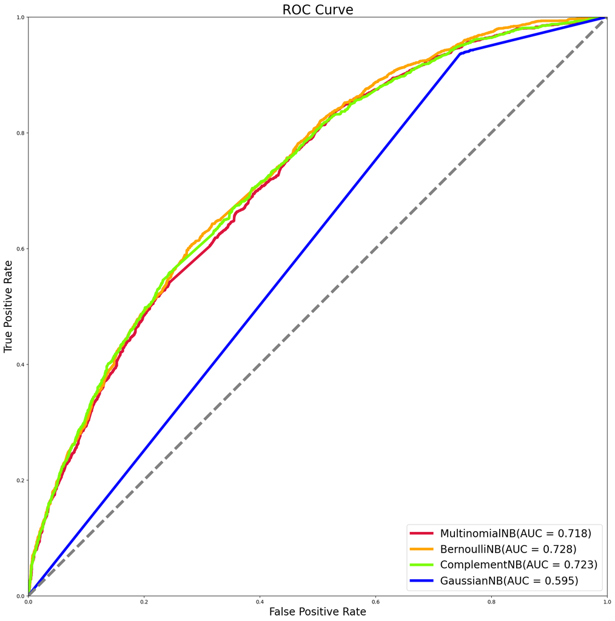

```python
def multi_models_roc(names, sampling_methods, colors, X_test, Y_test, save = True, dpin = 100):
    plt.figure(figsize=(20,20),dpi=dpin)

    for (name, method, colorname) in zip(names, sampling_methods, colors):
        y_test_predict = method.predict(X_test)
        y_test_predprob = method.predict_proba(X_test)[:,1]
        fpr, tpr, thresholds = roc_curve(y_test, y_test_predprob, pos_label = 1)
        plt.plot(fpr, tpr, lw = 5, label = '{}(AUC = {:.3f})'.format(name, auc(fpr,tpr)),color = colorname)
        plt.plot([0,1],[0,1],'--',lw=5,color='grey')
        plt.axis('square')
        plt.xlim([0,1])
        plt.ylim([0,1])
        plt.xlabel('False Positive Rate',fontsize = 20)
        plt.ylabel('True Positive Rate', fontsize = 20)
        plt.title('ROC Curve',fontsize = 25)
        plt.legend(loc = 'lower right', fontsize = 20)

    if save:
        plt.savefig('multi_models_roc.png')
    return plt
names = ['MultinomialNB','BernoulliNB','ComplementNB','GaussianNB']
sampling_methods = [mnb,by,cby,gnb]
colors = ['crimson','orange','lawngreen','blue']
roc_graph = multi_models_roc(names, sampling_methods, colors, x_test, y_test, save = True)
roc_graph
```

### 基于 ComplementNB 模型的训练效果

```python
cby = ComplementNB()
cbymodel = cby.fit(x_train,y_train)
y_predict_cby = cbymodel.predict(x_test)
print('Accuracy_scr = ',accuracy_score(y_predict_cby,y_test),' \nPrecision_scr = ',
                                       precision_score(y_predict_cby,y_test),' \nRecall_scr = ',
                                       recall_score(y_predict_cby,y_test))
```

```
Accuracy_scr =  0.6873500967117988
Precision_scr =  0.5635691169671753
Recall_scr =  0.531038989326944
```

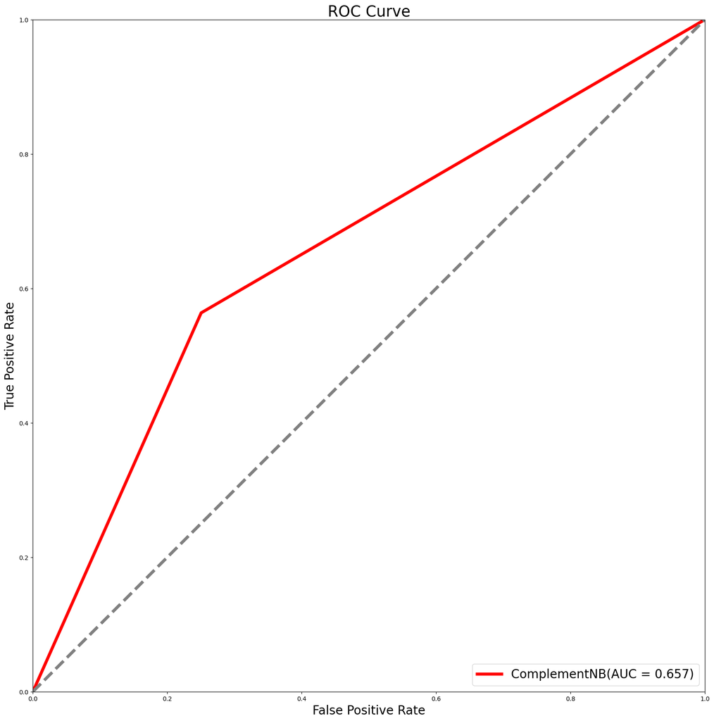

```python
plt.figure(figsize=(20,20),dpi=100)
y_test_predprob = cbymodel.predict_proba(x_test)[:,1]
fpr, tpr, thresholds = roc_curve(y_test, y_predict_cby, pos_label = 1)
plt.plot(fpr, tpr, lw = 5, label = '{}(AUC = {:.3f})'.format('ComplementNB', auc(fpr,tpr)),color = "red")
plt.plot([0,1],[0,1],'--',lw=5,color='grey')
plt.axis('square')
plt.xlim([0,1])
plt.ylim([0,1])
plt.xlabel('False Positive Rate',fontsize = 20)
plt.ylabel('True Positive Rate', fontsize = 20)
plt.title('ROC Curve',fontsize = 25)
plt.legend(loc = 'lower right', fontsize = 20)
```